# Question-4

## Classification using Naive Bayes

Example: Filtering spam SMS messages Classifiers based on Bayesian methods utilize training data to calculate an observed probability of each outcome based on the evidence provided by feature values. When the classifier is later applied to unlabeled data, it uses the observed probabilities to predict the most likely class for the new features. It’s a simple idea, but it results in a method that often has results on par with more sophisticated algorithms.

Exploring and preparing the data We will transform our data into a representation known as bag-of-words, which ignores word order and simply provides a variable indicating whether the word appears at all. Read the sms data into the sms data frame

```r
sms_raw <- read.csv("sms_spam.csv", stringsAsFactors = FALSE)
```

Examine the structure of the sms data

```r
str(sms_raw)
```

```
'data.frame':   5559 obs. of  2 variables:
 $ type: chr  "ham" "ham" "ham" "spam" ...
 $ text: chr  "Hope you are having a good week. Just checking in" "K..give back my thanks." "Am also doing in cbe only. But have to pay." "complimentary 4 STAR Ibiza Holiday or £10,000 cash needs your URGENT collection. 09066364349 NOW from Landline "| __truncated__ ...
```

Convert spam/ham to factor.

```r
sms_raw$type <- factor(sms_raw$type)
```

Examine the type variable more carefully

```r
str(sms_raw$type)
```

```
 Factor w/ 2 levels "ham","spam": 1 1 1 2 2 1 1 1 2 1 ...
```

```r
table(sms_raw$type)
```

```
 ham spam
4812  747
```

SMS messages are strings of text composed of words, spaces, numbers, and punctuation. Handling this type of complex data takes a lot of thought and effort. One needs to consider how to remove numbers and punctuation; handle uninteresting words such as and, but, and or; and how to break apart sentences into individual words. Thankfully, this functionality has been provided by the members of the R community in a text mining package titled `tm`.

Build a corpus using the text mining `(tm)` package.

```r
library(tm)
sms_corpus <- VCorpus(VectorSource(sms_raw$text))
```

Examine the SMS Corpus

```r
print(sms_corpus)
```

```
<<VCorpus>>
Metadata:  corpus specific: 0, document level (indexed): 0
Content:  documents: 5559
```

```r
inspect(sms_corpus[1:2])
```

```
<<VCorpus>>
Metadata:  corpus specific: 0, document level (indexed): 0
Content:  documents: 2

[[1]]
<<PlainTextDocument>>
Metadata:  7
Content:  chars: 49

[[2]]
<<PlainTextDocument>>
Metadata:  7
Content:  chars: 23
```

```r
as.character(sms_corpus[[1]])
```

```
[1] "Hope you are having a good week. Just checking in"
```

```r
lapply(sms_corpus[1:2], as.character)
```

```
$`1`
[1] "Hope you are having a good week. Just checking in"

$`2`
[1] "K..give back my thanks."
```

Clean up the corpus using `tm_map()`

Our first order of business will be to standardize the messages to use only lowercase characters. To this end, R provides a tolower() function that returns a lowercase version of text strings. In order to apply this function to the corpus, we need to use the tm wrapper function content_transformer() to treat tolower() as a transformation function that can be used to access the corpus. The full command is as follows:

```r
sms_corpus_clean <- tm_map(sms_corpus, content_transformer(tolower))
```

Show the difference between sms_corpus and corpus_clean

```r
as.character(sms_corpus[[1]])
```

```
[1] "Hope you are having a good week. Just checking in"
```

```r
as.character(sms_corpus_clean[[1]])
```

```
[1] "hope you are having a good week. just checking in"
```

Remove numbers

```r
sms_corpus_clean <- tm_map(sms_corpus_clean, removeNumbers)
```

Remove stop words

```r
sms_corpus_clean <- tm_map(sms_corpus_clean, removeWords, stopwords())
```

Remove punctuation

```r
sms_corpus_clean <- tm_map(sms_corpus_clean, removePunctuation)
```

Tip: create a custom function to replace (rather than remove) punctuation

```r
removePunctuation("hello...world")
```

```
[1] "helloworld"
```

```r
replacePunctuation <- function(x) { gsub("[[:punct:]]+", " ", x) }
replacePunctuation("hello...world")
```

```
[1] "hello world"
```

Illustration of word stemming

```r
library(SnowballC)
wordStem(c("learn", "learned", "learning", "learns"))
```

```
[1] "learn" "learn" "learn" "learn"
```

```r
sms_corpus_clean <- tm_map(sms_corpus_clean, stemDocument)
```

Eliminate unneeded whitespace

```r
sms_corpus_clean <- tm_map(sms_corpus_clean, stripWhitespace)
```

Examine the final clean corpus:

To view multiple documents, we’ll need to use as.character() on several items in the sms_corpus object. To do so, we’ll use the lapply() function, which is a part of a family of R functions that applies a procedure to each element of an R data structure. These functions, which include apply() and sapply() among others, are one of the key idioms of the R language

```r
lapply(sms_corpus[1:3], as.character)
```

```
$`1`
[1] "Hope you are having a good week. Just checking in"

$`2`
[1] "K..give back my thanks."

$`3`
[1] "Am also doing in cbe only. But have to pay."
```

```r
lapply(sms_corpus_clean[1:3], as.character)
```

```
$`1`
[1] "hope good week just check"

$`2`
[1] "kgive back thank"

$`3`
[1] "also cbe pay"
```

Create a document-term sparse matrix

```r
sms_dtm <- DocumentTermMatrix(sms_corpus_clean)
```

Alternative solution: create a document-term sparse matrix directly from the SMS corpus

```r
sms_dtm2 <- DocumentTermMatrix(sms_corpus, control = list(
  tolower = TRUE,
  removeNumbers = TRUE,
  stopwords = TRUE,
  removePunctuation = TRUE,
  stemming = TRUE
))
```

Alternative solution: using custom stop words function ensures identical result

```r
sms_dtm3 <- DocumentTermMatrix(sms_corpus, control = list(
  tolower = TRUE,
  removeNumbers = TRUE,
  stopwords = function(x) { removeWords(x, stopwords()) },
  removePunctuation = TRUE,
  stemming = TRUE
))
```

Compare the result

```r
sms_dtm
```

```
<<DocumentTermMatrix (documents: 5559, terms: 6542)>>
Non-/sparse entries: 42112/36324866
Sparsity           : 100%
Maximal term length: 40
Weighting          : term frequency (tf)
```

```r
sms_dtm2
```

```
<<DocumentTermMatrix (documents: 5559, terms: 6940)>>
Non-/sparse entries: 43185/38536275
Sparsity           : 100%
Maximal term length: 40
Weighting          : term frequency (tf)
```

```r
sms_dtm3
```

```
<<DocumentTermMatrix (documents: 5559, terms: 6542)>>
Non-/sparse entries: 42112/36324866
Sparsity           : 100%
Maximal term length: 40
Weighting          : term frequency (tf)
```

Creating training and test datasets

```r
sms_dtm_train <- sms_dtm[1:4169, ]
sms_dtm_test  <- sms_dtm[4170:5559, ]
```

Also save the labels

```r
sms_train_labels <- sms_raw[1:4169, ]$type
sms_test_labels  <- sms_raw[4170:5559, ]$type
```

Check that the proportion of spam is similar

```r
prop.table(table(sms_train_labels))
```

```
sms_train_labels
      ham      spam
0.8647158 0.1352842
```

```r
prop.table(table(sms_test_labels))
```

```
sms_test_labels
      ham      spam
0.8683453 0.1316547
```

Word cloud visualization:

A word cloud is a way to visually depict the frequency at which words appear in text data. The cloud is composed of words scattered somewhat randomly around the figure. Words appearing more often in the text are shown in a larger font, while less common terms are shown in smaller fonts. This type of figures grew in popularity recently, since it provides a way to observe trending topics on social media websites.

[figure not shown]

```r
library(wordcloud)
wordcloud(sms_corpus_clean, min.freq = 50, random.order = FALSE)
```

```
transformation drops documentstransformation drops documents
```

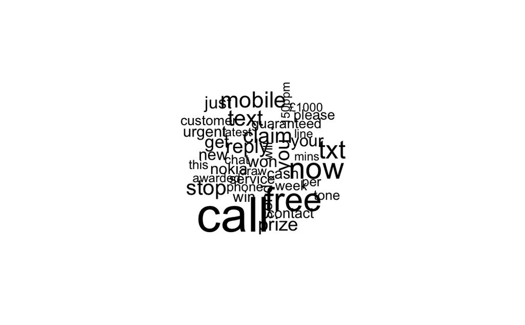

```r
spam <- subset(sms_raw, type == "spam")
ham  <- subset(sms_raw, type == "ham")
wordcloud(spam$text, max.words = 40, scale = c(3, 0.5))
```

```
transformation drops documentstransformation drops documents
```

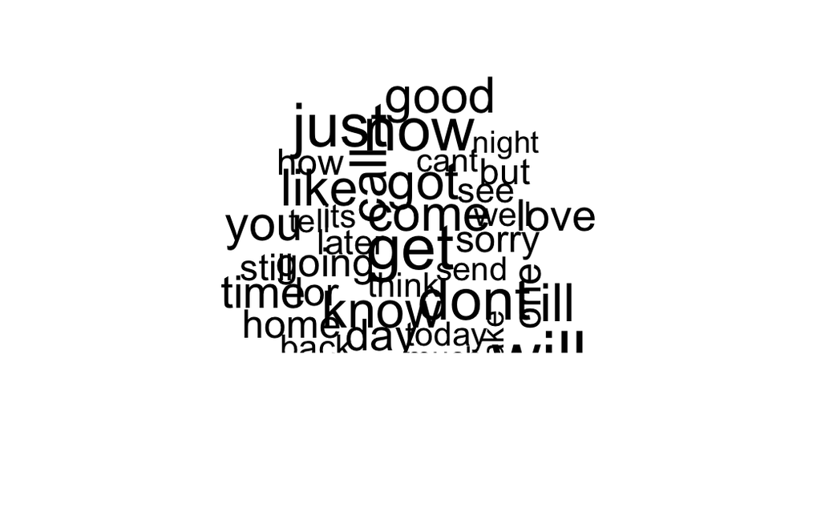

```r
wordcloud(ham$text, max.words = 40, scale = c(3, 0.5))
```

```r
sms_dtm_freq_train <- removeSparseTerms(sms_dtm_train, 0.999)
sms_dtm_freq_train
```

```
<<DocumentTermMatrix (documents: 4169, terms: 1102)>>
Non-/sparse entries: 24819/4569419
Sparsity           : 99%
Maximal term length: 19
Weighting          : term frequency (tf)
```

Indicator features for frequent words:

```r
findFreqTerms(sms_dtm_train, 5)
```

```
   [1] "£wk"                 "abiola"              "abl"
   [4] "abt"                 "accept"              "access"
   [7] "account"             "across"              "act"
  [10] "activ"               "actual"              "add"
  [13] "address"             "admir"               "adult"
  [16] "advanc"              "aft"                 "afternoon"
  [19] "age"                 "ago"                 "aha"
  [22] "ahead"               "aight"               "aint"
  [25] "air"                 "aiyo"                "alex"
  [28] "almost"              "alon"                "alreadi"
  [31] "alright"             "also"                "alway"
  [34] "angri"               "announc"             "anoth"
  [37] "answer"              "anymor"              "anyon"
  [40] "anyth"               "anytim"              "anyway"
  [43] "apart"               "app"                 "appli"
```

[output cut: 320 more lines]

Save frequently-appearing terms to a character vector

```r
sms_freq_words <- findFreqTerms(sms_dtm_train, 5)
str(sms_freq_words)
```

```
 chr [1:1137] "£wk" "abiola" "abl" "abt" "accept" "access" "account" "across" "act" ...
```

Create DTMs with only the frequent terms

```r
sms_dtm_freq_train <- sms_dtm_train[ , sms_freq_words]
sms_dtm_freq_test <- sms_dtm_test[ , sms_freq_words]
```

Convert counts to a factor

```r
convert_counts <- function(x) {
  x <- ifelse(x > 0, "Yes", "No")
}
```

Apply `convert_counts()` to columns of train/test data

```r
sms_train <- apply(sms_dtm_freq_train, MARGIN = 2, convert_counts)
sms_test  <- apply(sms_dtm_freq_test, MARGIN = 2, convert_counts)
```

Step 3: Training a model on the data:

Now that we have transformed the raw SMS messages into a format that can be represented by a statistical model, it is time to apply the Naive Bayes algorithm. The algorithm will use the presence or absence of words to estimate the probability that a given SMS message is spam. The Naive Bayes implementation we will employ is in the `e1071` package. This package was developed in the statistics department of the Vienna University of Technology (TU Wien), and includes a variety of functions for machine learning. If you have not done so already, be sure to install and load the package using the `install.packages("e1071")` and `library(e1071)` commands before continuing.

```r
library(e1071)
sms_classifier <- naiveBayes(sms_train, sms_train_labels)
```

Step 4: Evaluating model performance

To evaluate the SMS classifier, we need to test its predictions on unseen messages in the test data. Recall that the unseen message features are stored in a matrix named `sms_test`, while the class labels (spam or ham) are stored in a vector named `sms_test_labels`. The `predict()` function is used to make the predictions. We will store these in a vector named `sms_test_pred`. We will simply supply the function with the names of our classifier and test dataset, as shown:

```r
sms_test_pred <- predict(sms_classifier, sms_test)
library(gmodels)
CrossTable(sms_test_pred, sms_test_labels,
           prop.chisq = FALSE, prop.c = FALSE, prop.r = FALSE,
           dnn = c('predicted', 'actual'))
```

```
   Cell Contents
|-------------------------|
|                       N |
|         N / Table Total |
|-------------------------|


Total Observations in Table:  1390


             | actual
   predicted |       ham |      spam | Row Total |
-------------|-----------|-----------|-----------|
         ham |      1201 |        30 |      1231 |
             |     0.864 |     0.022 |           |
-------------|-----------|-----------|-----------|
        spam |         6 |       153 |       159 |
             |     0.004 |     0.110 |           |
-------------|-----------|-----------|-----------|
Column Total |      1207 |       183 |      1390 |
-------------|-----------|-----------|-----------|
```

Step 5: Improving model performance

You may have noticed that we didn’t set a value for the Laplace estimator while training our model. This allows words that appeared in zero spam or zero ham messages to have an indisputable say in the classification process. Just because the word “ringtone” only appeared in the spam messages in the training data, it does not mean that every message with this word should be classified as spam. We’ll build a Naive Bayes model as done earlier, but this time set laplace = 1:

```r
sms_classifier2 <- naiveBayes(sms_train, sms_train_labels, laplace = 1)
sms_test_pred2 <- predict(sms_classifier2, sms_test)
CrossTable(sms_test_pred2, sms_test_labels,
           prop.chisq = FALSE, prop.c = FALSE, prop.r = FALSE,
           dnn = c('predicted', 'actual'))
```

```
   Cell Contents
|-------------------------|
|                       N |
|         N / Table Total |
|-------------------------|


Total Observations in Table:  1390


             | actual
   predicted |       ham |      spam | Row Total |
-------------|-----------|-----------|-----------|
         ham |      1202 |        28 |      1230 |
             |     0.865 |     0.020 |           |
-------------|-----------|-----------|-----------|
        spam |         5 |       155 |       160 |
             |     0.004 |     0.112 |           |
-------------|-----------|-----------|-----------|
Column Total |      1207 |       183 |      1390 |
-------------|-----------|-----------|-----------|
```